# Probability & Statistics_Part2

### Box-Cox Transformation :

We have seen that , Given a random varibable which was log-normally distributed , We can easily converted it into Gaussian Distributed random varibale Y by taking natural log of all data points.

- In Machine Learning, Most of the time we try assume or to convert other random variable into Gaussian Random variable,Because We can derive many insights from it.

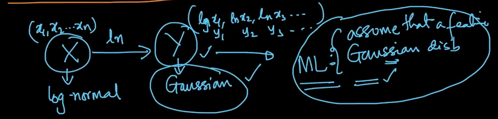

- Q. How Power Transform Works ?

  Ans :

  ```
        Let
            X : [x1, x2, x3 ... xn ] = A Pareto Distributed Random Varibale
            Y : [y1, y2, y3 ... yn]= Gaussian Distributed Random Varibale

        We want to convert this X into Y
  ```

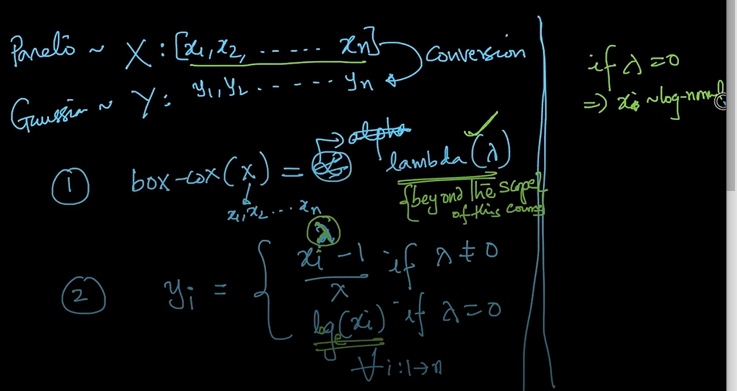

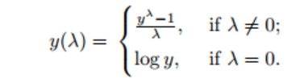

Note :

- ```
     If lambda = 0 , It means that X is log-Normal Distributed, that's why we are just taking Natural Logrithm to Y in this condition(lambda=0) to convert into Gaussian Distribution.
  ```

- don't much worry about " lambda = box-cox(X) " It is out of scope

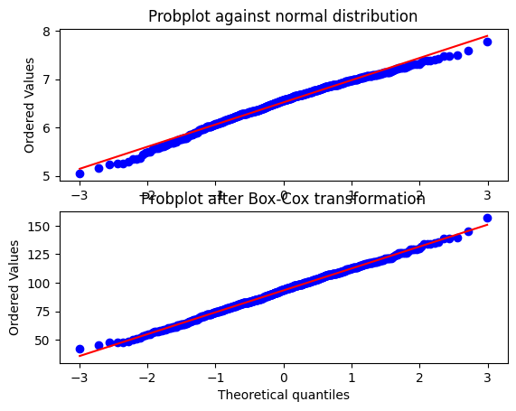

```python
#Example
from scipy import stats
import matplotlib.pyplot as plt

# We generate some random variates from a non-normal distribution(Gamma Distribution) and
# make a probability plot for it, to show it is non-normal in the tails:

fig = plt.figure()
ax1 = fig.add_subplot(211)
x = stats.loggamma.rvs(5, size=500) + 5
prob = stats.probplot(x, dist=stats.norm, plot=ax1) # this is Q-Q plot
ax1.set_xlabel('')
ax1.set_title('Probplot against normal distribution')
print("\n")

# We now use boxcox to transform the data so it’s closest to normal:
ax2 = fig.add_subplot(212)
Y, _ = stats.boxcox(x) # it will convert in Gaussian Distribution
prob = stats.probplot(Y, dist=stats.norm, plot=ax2) # Q-Q plot
ax2.set_title('Probplot after Box-Cox transformation')
plt.show()



# ref :https://docs.scipy.org/doc/scipy/reference/generated/scipy.stats.boxcox.html
```

- We Can See, using Q-Q Plot that Last Graph is Convert into Gaussian Distribution

#### Applications of non-gaussian distributions

Q. Why Distribution are important ?

```
Ans : If we have less amount of data ,then It is difficult to make insight and conclusion from it using mean, median ,mode, percentile (without using distribution)

Since Distributions are well studied in lots of area of science,
If we fit our data to any well studied-distribution, then we can get more insights from it without any effort.

That's why Distribution are important,, and there are 100's of distribution, Distribution gives a theoratical Model about Data.
that used in different area of Maths, Science, Machine Learning, Biology Etc.

Moreover,

We check a distribution is Normal or Not, Using Q-Q plot or K-S Test.
We can convert(Not Always) non-gaussian Distribution to Gaussian Distribution by using Box-Cox Transform.
```

#### Co-Variance :

Q. How to measure Relationships between Random Variables ?

```
Ans :
let we have 'n' observation of height & Weights of Student.

    X = Random Varibable of Height of student
    Y = Random Varibable of Weights of student


There are 3 measure to find Relationships bw Random Variables :
```

1. co-variance
2. pearson correlation coefficient (PCC)
3. Spearman Rank correlation coefficient (SRCC)

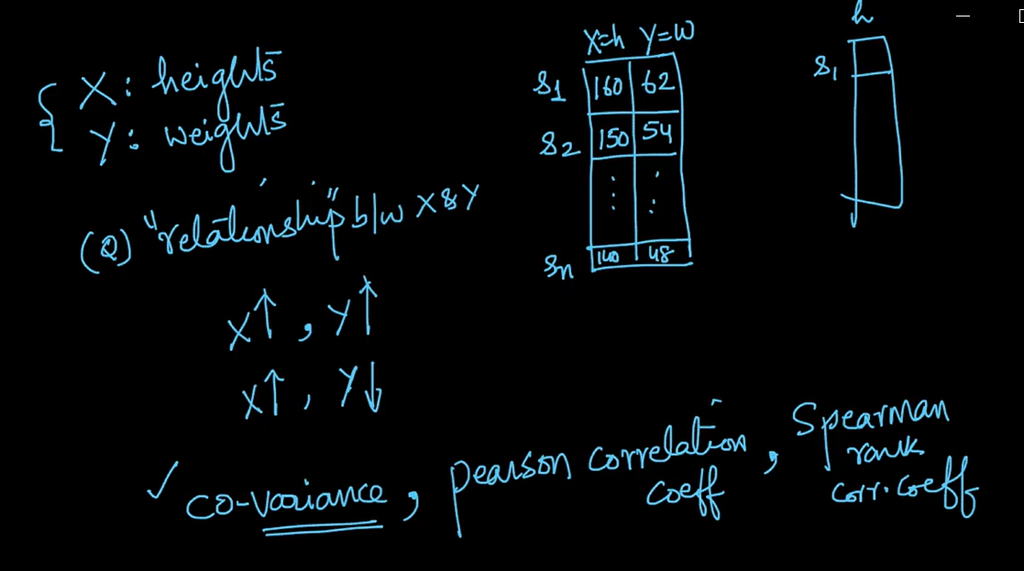

- covariance is a measure of the joint variability of two random variables.
- The variance can also be thought of as the covariance of a random variable with itself.

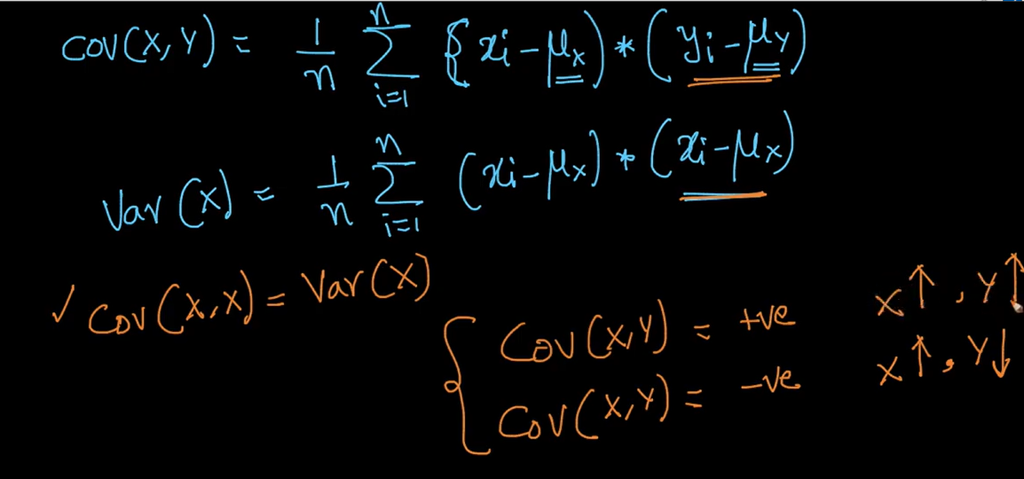

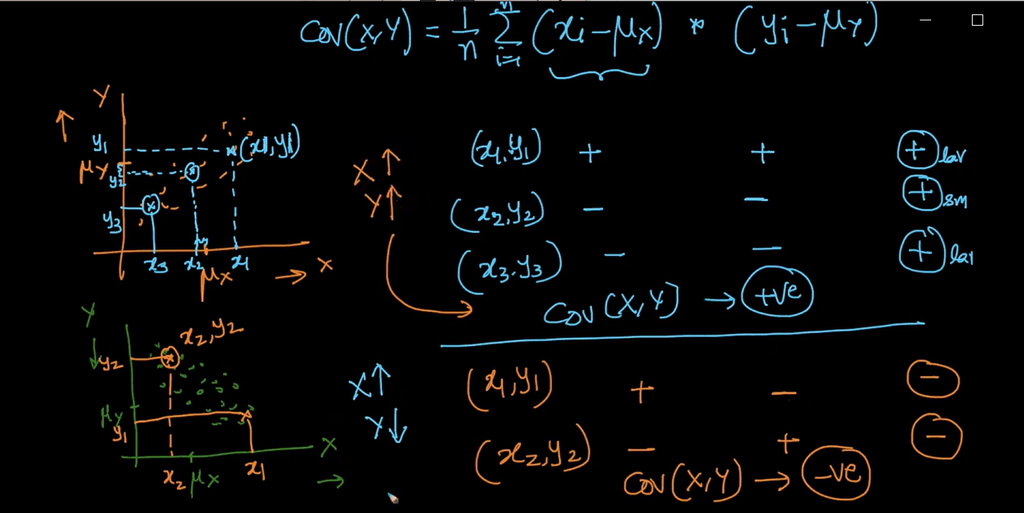

- Sign of Co-varinace helpful to know direct or inverse relationship bw two Random Varibable, But Value of Co-varinace does not give any idea about relationship bw them
- Major Diasadvantage :

  ```
    For the Same DataSet, If we Measure data in different Unit and Apply co-variance , then co-variance is not the same
  ```

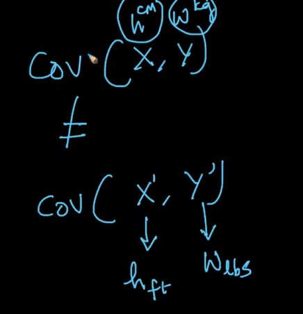

#### Pearson Correlation coefficient (Rho) :

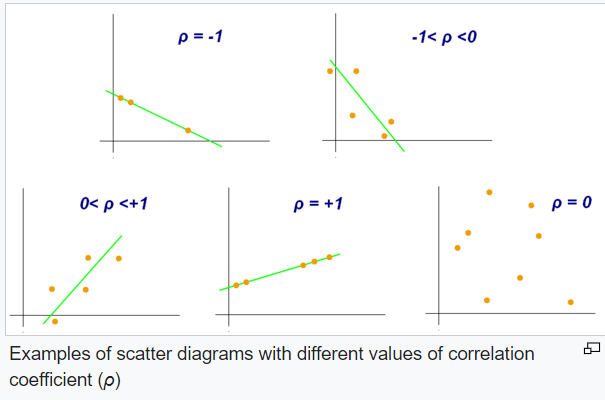

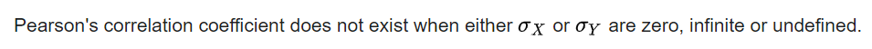

Most Of the time , It tells about linear relationship between two Random Variable

Limitation of Pearson Correlation coefficient

1. It doesn't tell about how fast a random variable increase with respect to other random variable. See below Example, In all cases , PCC = 1 and -1 ,while These curve has different rate of increasing & decreasing.

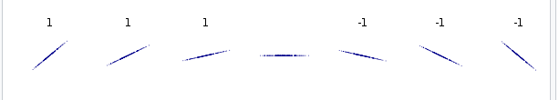

2. It is unable to explain complex non-linear relationship bw random variable. It directly tells that PCC=0, while we can see that there has been some non-linear relationship between Random Varibale.

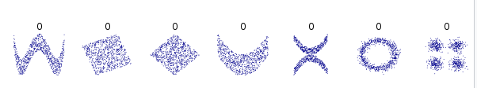

3. Pearson Correlation Coefficient is not good in non-linear relationship, While Spearman's Rank correlation coefficient tells about monotonic relationships (whether linear or not)

Ex : In case of Non-decreasing function

[output not shown]

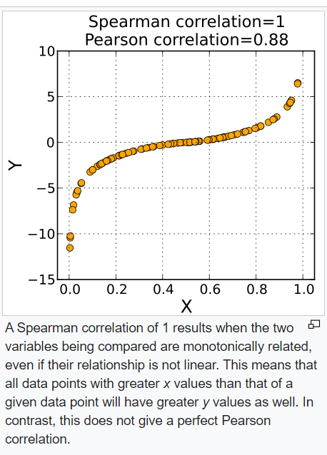

#### Spearman's Rank Correlation Coefficient :

The Spearman correlation between two variables is equal to the Pearson correlation between the rank values of those two variables;

Let, X = Height of students in cm's Y = Weight of Student in Kgs

Now Creating two New random Variable Which are Rank of X (rx) , and Rank of Y (ry)

```
rx = sort(in ascending) the varibale X and assign 1st Rank to the least Value of X,
lly for ry.
```

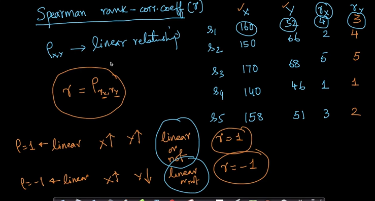

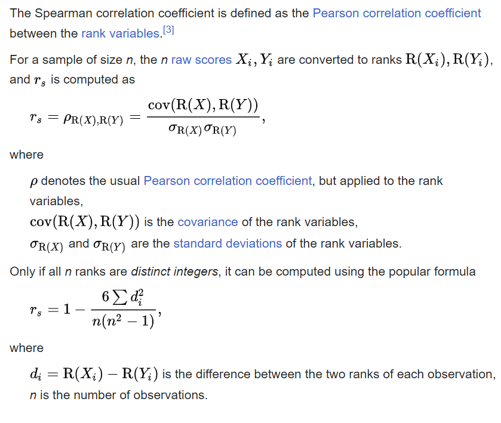

- Advantage of Spearman's Rank Correlation Co-efficient over Pearson :
1. if X is increasing with Y , then It gives value = +1 ,It does not care about relationship is linear or not, Because It calculate using Rank of X,Y instead of direct value of X and Y , and ranks are always strictly increasing.

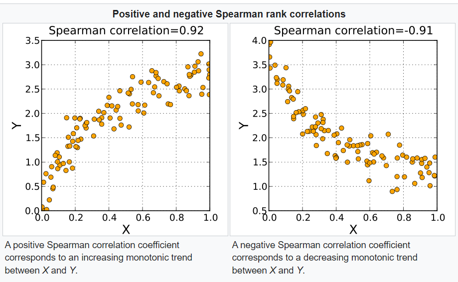

2. It is less sensitive to ouliers, So It handles the data efficiently.

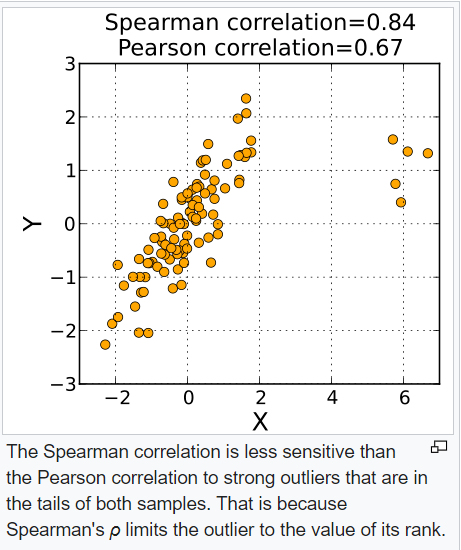